# Types, Anomalies, and Missingness

Data cleaning 2 · Session 6

DTR

2026-11-18

# Welcome

## Recall (30 seconds, silent)

1. What does `"[^\\x00-\\x7F]"` find?
2. Why is `parse_number()` risky on `"165 lb"` and `"72 kg"`?
3. Why do we use a lookup table instead of a long `ifelse()`?
1. Any character outside plain **ASCII**: lookalikes, accents
2. It drops the **unit**, so pounds and kilograms mix
3. A reviewer can **read** it, and `anti_join()` shows what is unmapped

## Today’s route

- **Types**: dates arrive as text in many formats
- **Sentinels**: numbers that mean “nothing”
- **Outliers**: domain rules first, plots second
- **Validity rules**: write them as code
- **Missingness**: who is missing, and why does it matter?
- **Imputation**: judge it by the distribution

Hands-on today: **code it**, **prompt it**, **assess it**.

## Set up for the three tasks

```r
library(tidyverse)
vitals <- read_csv("data/s6_vitals.csv")
users <- read_csv("data/s6_users.csv")
steps_sim <- read_csv("data/s6_steps_sim.csv")
```

The files are on the [course site](https://dtrstats.github.io/stat531-lectures/), Have your AI assistant open too.

## Where we left off

Session 5 fixed **text**: patterns, lookalikes, categories.

Today is **numbers, dates, and holes**. The order is the same: **flag** first, **remediate** patterns, and only then **impute or drop**.

AI can fill a hole in one line. It will not tell you who the hole belongs to. That is your job as navigator.

# Dates and types

## Text is not a date

```r
sort(c("10", "9", "100"))
```

```
#> [1] "10"  "100" "9"
```

```r
sort(c("2026-01-10", "2026-01-9", "2026-01-100"))
```

```
#> [1] "2026-01-10"  "2026-01-100" "2026-01-9"
```

A column stored as text sorts, compares, and subtracts as **text**. Types are part of the model.

## One column, many formats

```r
ts_raw
```

```
#> [1] "2026-01-05 07:30"     "01/05/2026 7:30 AM"   "5 Jan 2026 07:30"
#> [4] "2026-01-05T07:30:00Z" "Jan 5, 2026"          "yesterday"
```

Timestamps from different devices, typed or exported differently.

## `ymd_hms()` parses only what it knows

```r
ymd_hms(ts_raw, quiet = TRUE)
```

```
#> [1] NA                        NA
#> [3] NA                        "2026-01-05 07:30:00 UTC"
#> [5] NA                        NA
```

```r
sum(is.na(ymd_hms(ts_raw, quiet = TRUE)))
```

```
#> [1] 5
```

Five of six became `NA`. No error: the function did what you asked.

**Bug:** an AI that stops here has just discarded 83% of the column.

## Give it a list of orders

```r
parsed <- parse_date_time(
  ts_raw,
  tz = "UTC",
  quiet = TRUE,
  orders = c("Ymd HM", "mdY IMp", "dbY HM", "YmdHMSz", "bdY")
)
tibble(ts_raw, parsed, ok = !is.na(parsed))
```

```
#> # A tibble: 6 x 3
#>   ts_raw               parsed              ok
#>   <chr>                <dttm>              <lgl>
#> 1 2026-01-05 07:30     2026-01-05 07:30:00 TRUE
#> 2 01/05/2026 7:30 AM   2026-01-05 07:30:00 TRUE
#> 3 5 Jan 2026 07:30     2026-01-05 07:30:00 TRUE
#> 4 2026-01-05T07:30:00Z 2026-01-05 07:30:00 TRUE
#> 5 Jan 5, 2026          2026-01-05 00:00:00 TRUE
#> 6 yesterday            NA                  FALSE
```

Each order is a pattern: `Y` year, `m` month, `d` day, `HM` hour and minute, `IMp` 12-hour clock with AM/PM.

## Count what failed

The check that matters: **how many rows did not parse, and why?**

```r
tibble(ts_raw, parsed) |>
  filter(is.na(parsed))
```

```
#> # A tibble: 1 x 2
#>   ts_raw    parsed
#>   <chr>     <dttm>
#> 1 yesterday NA
```

`"yesterday"` is not a date. It stays `NA` and gets **flagged**. Never fill it in.

## The day-month trap

```r
d <- c("01/05/2026", "13/05/2026", "05/05/2026", "02/11/2026")
a <- as.numeric(str_extract(d, "^\\d+"))
b <- as.numeric(str_extract(d, "(?<=/)\\d+"))
tibble(d, ambiguous = a <= 12 & b <= 12 & a != b)
```

```
#> # A tibble: 4 x 2
#>   d          ambiguous
#>   <chr>      <lgl>
#> 1 01/05/2026 TRUE
#> 2 13/05/2026 FALSE
#> 3 05/05/2026 FALSE
#> 4 02/11/2026 TRUE
```

`01/05/2026` is January 5 or May 1. **Code cannot tell.** Ask which **locale** the device used, then set the order.

## Time zones (FLEX)

```r
t <- ymd_hms("2026-01-05 07:30:00", tz = "America/Los_Angeles")
t
```

```
#> [1] "2026-01-05 07:30:00 PST"
```

```r
with_tz(t, "UTC")
```

```
#> [1] "2026-01-05 15:30:00 UTC"
```

Same instant, different clock. Store in **UTC**, convert for display.

# Sentinels and missing markers

## Four kinds of “nothing”

| Looks like | Is it missing? |
| --- | --- |
| `NA` | yes: R’s missing value |
| `NaN` | yes: not a number (`0/0`) |
| `""`, `"n/a"`, `"NULL"` | text pretending to be a value |
| `-999`, `-1`, `9999` | a **sentinel**: a number that means “no data” |

`NULL` is different: it means “no object” and cannot sit inside a data frame column.

## One sentinel, wrong average

```r
summary(vitals$hr)
```

```
#>    Min. 1st Qu.  Median    Mean 3rd Qu.    Max.
#>  -999.0    64.0    72.0    41.2    79.0   300.0
```

The mean heart rate is **41**. A heart that slow does not exist. The `-999`s dragged it down.

## Look at the extremes

```r
vitals |>
  filter(hr < 30 | hr > 220) |>
  count(hr, sort = TRUE)
```

```
#> # A tibble: 3 x 2
#>      hr     n
#>   <dbl> <int>
#> 1  -999    29
#> 2     0     8
#> 3   300     4
```

`-999` is a **sentinel**. `0` and `300` are different: not a code, just impossible.

## Turn sentinels into `NA`

```r
vit_na <- vitals |> mutate(hr = na_if(hr, -999), steps = na_if(steps, -1))
colSums(is.na(vit_na))
```

```
#>    hr steps
#>    29    25
```

When reading a file: `read_csv(path, na = c("", "NA", "-999"))`.

**Bug:** is `-1` a sentinel? In steps, yes. In a temperature column, it is a real reading. **The data dictionary decides**, not a regex or an AI.

## `NaN` is not `NA` (FLEX)

```r
x <- c(1, NA, 0 / 0)
is.na(x)
```

```
#> [1] FALSE  TRUE  TRUE
```

```r
is.nan(x)
```

```
#> [1] FALSE FALSE  TRUE
```

`is.na()` catches both. `is.nan()` catches only the second.

# Bounds and outliers

## Impossible first, unusual second

| Question | Tool |
| --- | --- |
| Can this value exist at all? | **Domain bound** (a rule you know) |
| Is it far from the rest? | z-score or IQR rule |
| Is it odd only in combination? | Derived feature or distance |

A heart rate of **300** is impossible. A heart rate of **125** is unusual. Different actions.

## Fixed bounds: flag, do not delete

```r
vit_na |>
  mutate(
    hr_flag = case_when(
      is.na(hr) ~ "missing",
      between(hr, 30, 220) ~ "ok",
      .default = "impossible"
    )
  ) |>
  count(hr_flag)
```

```
#> # A tibble: 3 x 2
#>   hr_flag        n
#>   <chr>      <int>
#> 1 impossible    12
#> 2 missing       29
#> 3 ok           959
```

Keep the row. Keep the flag. A later step decides what to do.

## Task 1: code it

`vitals` has sentinels (`-999`, `-1`) and impossible heart rates (`0`, `300`).

**Code it (5 min).** 1. Turn the sentinels into `NA`. 2. Flag heart rates outside **30 to 220** as `"impossible"`. 3. Compare the mean heart rate **before** and **after**, using only `"ok"` rows.

## The answer

```r
c(raw = mean(vitals$hr), clean = mean(hr_ok$hr))
```

```
#>      raw    clean
#> 41.20000 71.91971
```

```r
count(vit, hr_flag)
```

```
#> # A tibble: 3 x 2
#>   hr_flag        n
#>   <chr>      <int>
#> 1 impossible    12
#> 2 missing       29
#> 3 ok           959
```

**Bug:** the raw mean was off by **30 bpm**, from sentinels alone.

## z-scores: how far from the rest?

$$z = \frac{x - \bar{x}}{s}$$

For roughly bell-shaped data, about **0.3%** of values are beyond $|z| > 3$.

```r
nrow(hr_ok)
```

```
#> [1] 959
```

```r
c(expected = round(0.0027 * nrow(hr_ok), 1), found = sum(abs(zs(hr_ok$hr)) > 3))
```

```
#> expected    found
#>      2.6      5.0
```

Close to what a bell curve gives: nothing alarming here.

## The IQR rule

A value is “unusual” if it is beyond **1.5 x IQR** from the quartiles. This is the rule a boxplot uses.

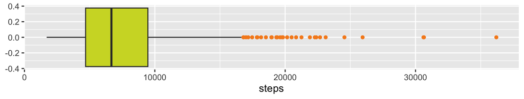

```r
ggplot(steps_ok, aes(x = steps)) +
  geom_boxplot(fill = "#cfd82d", outlier.color = "#f68b1f")
```

## z or IQR? It depends on the shape

```r
tibble(
       variable = c("hr (bell-shaped)", "steps (skewed)"),
       z_beyond_3 = c(
              sum(abs(zs(hr_ok$hr)) > 3),
              sum(abs(zs(steps_ok$steps)) > 3)
       ),
       iqr_rule = c(sum(iqr_flag(hr_ok$hr)), sum(iqr_flag(steps_ok$steps))),
       n = c(nrow(hr_ok), nrow(steps_ok))
)
```

```
#> # A tibble: 2 x 4
#>   variable         z_beyond_3 iqr_rule     n
#>   <chr>                 <int>    <int> <int>
#> 1 hr (bell-shaped)          5        8   959
#> 2 steps (skewed)           14       32   975
```

Skewed data flags many “outliers” on the long tail. Rare is **not** wrong.

## Look in context

1. **Impossible?** A bound says so: flag as an error.
2. **Plausible but extreme?** Keep it: it may be your most interesting data.
3. **Repeated?** The same odd value many times: look for a code, not a person.

Outliers are **questions**, not verdicts. Flag, look, document.

## Odd only in combination

```r
hw |> filter(id == 501) |> select(h, w, zh, zw, bmi, zb)
```

```
#> # A tibble: 1 x 6
#>       h     w    zh    zw   bmi    zb
#>   <dbl> <dbl> <dbl> <dbl> <dbl> <dbl>
#> 1   190    45  2.17 -2.07  12.5 -3.73
```

Height and weight each look normal: $|z| < 3$. But **BMI** is 12.5, far below normal.

A **derived feature** can catch what each column alone cannot.

## Mahalanobis distance (FLEX)

$$D^2 = (\mathbf{x} - \boldsymbol{\mu})^\top \, \boldsymbol{\Sigma}^{-1} \, (\mathbf{x} - \boldsymbol{\mu})$$

$\mathbf{x}$: one row’s values · $\boldsymbol{\mu}$: the column means · $\boldsymbol{\Sigma}$: their covariance matrix

```r
hw |> filter(md > qchisq(.99, 2)) |> select(id, h, w, md) |>
  arrange(desc(md)) |> head(3)
```

```
#> # A tibble: 3 x 4
#>      id     h     w    md
#>   <int> <dbl> <dbl> <dbl>
#> 1   501   190    45  27.7
#> 2   252   143    30  12.2
#> 3    12   194   111  11.8
```

$\boldsymbol{\Sigma}^{-1}$ scales by spread **and** accounts for how the variables move together. Cutoff: $\chi^2_2$ at 99%, about **9.2**.

# Validity rules

## Dimensions of data quality

| Dimension | The question |
| --- | --- |
| **Validity** | Does it follow the rules? |
| **Accuracy** | Is it close to the truth? |
| **Consistency** | Does it agree with itself and other tables? |
| **Uniformity** | Same units, same format? |
| **Completeness** | Is everything we need here? |

A value can be **valid and still wrong**: `120` is a valid heart rate that may be false.

## Validity rules you can write as code

| Rule type | Example |
| --- | --- |
| Data type | `age` is numeric |
| Range | `age` between 0 and 120 |
| Mandatory | `id` is never `NA` |
| Unique | `id` appears once |
| Set membership | `device` is `watch`, `band`, or `ring` |
| Pattern | `zip` is exactly 5 digits |
| Cross-field | `end` is not before `start` |

## Rules become counts

```r
users |>
  summarize(
    id_missing = sum(is.na(id)),
    age_range = sum(!between(age, 0, 120), na.rm = TRUE),
    device_set = sum(!device %in% c("watch", "band", "ring")),
    zip_pattern = sum(!str_detect(zip, "^\\d{5}$"), na.rm = TRUE)
  ) |>
  pivot_longer(everything(), names_to = "rule", values_to = "failing")
```

```
#> # A tibble: 4 x 2
#>   rule        failing
#>   <chr>         <int>
#> 1 id_missing        1
#> 2 age_range         2
#> 3 device_set        2
#> 4 zip_pattern       2
```

A table of **failing counts** is a report you can rerun on every new file.

## Task 2: prompt it

Rules for `users` (from the data dictionary):

`id`: never missing, unique · `age`: 0 to 120 · `device`: `watch`, `band`, `ring` · `zip`: 5 digits · `end` not before `start`

**Prompt it (6 min).** 1. **Count by hand** the failing rows per rule. 2. Prompt your AI for `check_rules(df)`: one row per rule, with the failing count. It must **not change** the data. 3. Run it. Do your counts match?

## The answer

```r
users |>
  summarize(
    id_missing = sum(is.na(id)),
    id_duplicated = sum(duplicated(id[!is.na(id)])),
    age_range = sum(!between(age, 0, 120), na.rm = TRUE),
    device_set = sum(!device %in% c("watch", "band", "ring")),
    zip_pattern = sum(!str_detect(zip, "^\\d{5}$"), na.rm = TRUE),
    end_early = sum(end < start)
  )
```

```
#> # A tibble: 1 x 6
#>   id_missing id_duplicated age_range device_set zip_pattern end_early
#>        <int>         <int>     <int>      <int>       <int>     <int>
#> 1          1             1         2          2           2         4
```

## Decisions hidden in the counts

- **`NA` age**: not out of range. It is **missing**, a different problem
- **Duplicated `id`**: count the **extra** copies, or both?
- **`"Watch"`**: invalid by the rule. Case-fold first, or flag it?
- **`97201-1234`**: malformed, or a valid ZIP+4?

The rule table is code **and** documentation. Write the decision down.

# Missingness

## Why is it missing?

| Type | Meaning | Example |
| --- | --- | --- |
| **Structural** | cannot exist | “last pregnancy date” for a man |
| **MCAR** | unrelated to anything | a random sync failure |
| **MAR** | related to **other columns** | old devices drop steps |
| **MNAR** | related to the **missing value itself** | heart rate dropped when it is high |

Real data is rarely MCAR. The mechanism decides what is safe to do.

## Diagnose: is missingness the same everywhere?

```r
steps_sim |>
  summarize(missing = mean(is.na(steps)), n = n(), .by = device)
```

```
#> # A tibble: 2 x 3
#>   device missing     n
#>   <chr>    <dbl> <int>
#> 1 new     0.0798  1203
#> 2 legacy  0.512    797
```

Legacy devices lose **51%** of steps, new devices **8%**. That is not random.

You can **describe** this pattern. You cannot **prove** the cause from the file.

## Drop the rows? Look at who is left

```r
steps_sim |>
  summarize(
    all_rows = mean(device == "legacy"),
    complete_rows = mean(device[!is.na(steps)] == "legacy")
  )
```

```
#> # A tibble: 1 x 2
#>   all_rows complete_rows
#>      <dbl>         <dbl>
#> 1    0.398         0.260
```

Legacy devices were **40%** of users, but only **26%** of complete rows.

**Bug:** dropping rows with `NA` removes legacy users first. The model then learns mostly from **new-device** users.

## MNAR leaves no trace

If heart rate goes missing **because** it was high, no other column shows it.

Only **context** can raise the suspicion: how does the sensor behave when the wearer is exercising?

What you can do: ask the source, compare with another source, or test how much the answer **changes** under different assumptions (a **sensitivity analysis**).

# Imputation

## Options, and the rule of thumb

| Option | When |
| --- | --- |
| **Drop rows** | few missing (under about 5 to 10%) and MCAR |
| **Drop the variable** | mostly missing, little value |
| **Impute** | MAR, and the variable is a predictor |
| **Declare unusable** | too much missing, or MNAR with no way to check |

**Never impute the label or the outcome** you are trying to predict.

## Mean imputation: the tempting one

```r
mean_imp <- steps_sim |>
  mutate(steps = if_else(is.na(steps), mean(steps, na.rm = TRUE), steps))

c(true_sd = sd(steps_sim$steps_true), after_mean_imp = sd(mean_imp$steps))
```

```
#>        true_sd after_mean_imp
#>       2564.128       2193.206
```

The mean stays put. The **spread shrinks**, because one value now fills 25% of the column.

## What it does to the shape

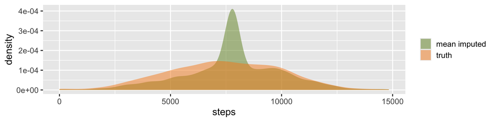

```r
bind_rows(
        truth = steps_sim |> transmute(steps = steps_true),
        `mean imputed` = mean_imp |> select(steps),
        .id = "version"
) |>
        ggplot(aes(x = steps, fill = version)) +
        geom_density(alpha = 0.5, color = NA) +
        scale_fill_manual(values = c("#6d8d24", "#f68b1f"), name = NULL)
```

## Multiple imputation with `mice`

```r
library(mice)
dat <- steps_sim |>
  select(steps, device, age) |>
  mutate(device = factor(device))
imp <- mice(
  dat,
  m = 5,
  method = "pmm",
  donors = 20,
  printFlag = FALSE,
  seed = 531
)
```

- `m = 5`: five completed datasets, to carry the **uncertainty**
- `pmm`: fill each hole with an **observed** value from a similar row
- Analyze each dataset, then **pool**

## Judge it by the distribution

```r
stats <- \(x) c(mean = mean(x), sd = sd(x))
pooled <- sapply(1:5, \(i) stats(complete(imp, i)$steps))

rbind(
      truth = stats(steps_sim$steps_true),
      `drop rows` = stats(na.omit(steps_sim$steps)),
      `mean imputed` = stats(mean_imp$steps),
      `mice (pooled)` = rowMeans(pooled)
) |>
      round()
```

```
#>               mean   sd
#> truth         7419 2564
#> drop rows     7791 2536
#> mean imputed  7791 2193
#> mice (pooled) 7404 2604
```

Real data has **no truth column**. There you compare distributions and **group means** before and after, never single imputed values.

## Task 3: the AI’s answer

Asked: “Fill in the missing steps so the column is complete.”

```r
steps_sim |>
  mutate(steps = if_else(is.na(steps), mean(steps, na.rm = TRUE), steps)) |>
  summarize(mean = mean(steps), sd = sd(steps), missing = sum(is.na(steps)))
```

```
#> # A tibble: 1 x 3
#>    mean    sd missing
#>   <dbl> <dbl>   <int>
#> 1 7791. 2193.       0
```

The AI then wrote: “No missing values remain, and the mean is unchanged, so no bias was introduced.”

## Task 3: assess it

**Assess it (5 min).** Run it. Compare with `steps_true` and with the group means by `device`. **Read**, **Run**, **Restate**.

1. Is the claim “no bias” true? Check **two** things.
2. What happened to the **spread**?
3. What does it do to legacy users?
4. What would you ask for instead?

## What was wrong

- **“Unchanged mean”** is guaranteed by the method, so it proves nothing
- That mean is **already biased**: legacy devices are under-represented
- The **spread shrinks**: intervals will be too narrow
- **Legacy users** are filled with the new-device average

A complete column is not a correct column. Compare **distributions and groups**.

# Wrap-up

## Four things to remember

1. **Parse with a list of orders**, count the failures, and never let code guess an ambiguous date.
2. **Impossible first, unusual second.** Sentinels and bounds, then z or IQR. Flag, do not delete.
3. **Rules are code.** A table of failing counts is a report you can rerun.
4. **Missingness has a pattern.** Check who is missing before you drop or fill, and judge imputation by the **distribution**.

## Next up

Wed 11/25, Session 7: **the cleaning lab kickoff**. That is the Wednesday before Thanksgiving, so it is designed to work on your own schedule.

The **handout** has the full explanations, extra practice, and the `pointblank` appendix.

# Appendix

## Unit tests with `testthat`

```r
library(testthat)

test_that("heart rate is in range after cleaning", {
  expect_true(all(between(clean$hr, 30, 220), na.rm = TRUE))
  expect_equal(sum(clean$hr == -999, na.rm = TRUE), 0)
})
```

A failing test stops the script. Run it after every cleaning step.

## Validation reports with `pointblank` (not run)

```r
# install.packages("pointblank")  # once
library(pointblank)

users |>
  create_agent() |>
  col_vals_between(age, 0, 120, na_pass = TRUE) |>
  col_vals_in_set(device, c("watch", "band", "ring")) |>
  col_vals_regex(zip, "^\\d{5}$", na_pass = TRUE) |>
  interrogate()
```

Same idea as `check_rules()`, with a formatted report.